# ClusterAnalysis_colleges

Kat Devlin

2017年9月7日

Minkowski distance - either Euclidean or Manhattan - seems most appropriate for the data, which includes non-redundant continuous variables. If the data were in the form of counts we would look toward, for instance, canberra distance instead.

We will need to standardize data to perform the distance calculations. All variables in original set are on separate scales.

```r
round(sqrt(apply(x[,-1],2,var)),2)
```

```
##      SAT    Top10   Accept  SFRatio Expenses     Grad
##     1.08    19.43    19.73     4.07    14.42     9.06
```

```r
x.scale <- scale(x[,-1])
rownames(x.scale) = x[,1]
```

The data now appears to be multivariate normal.

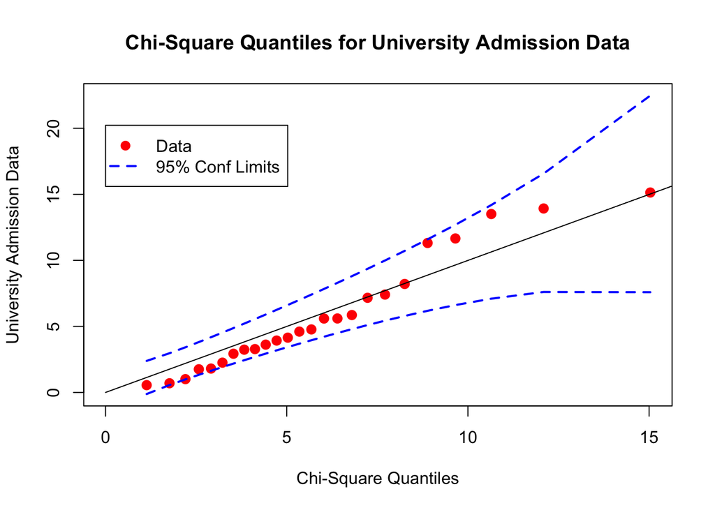

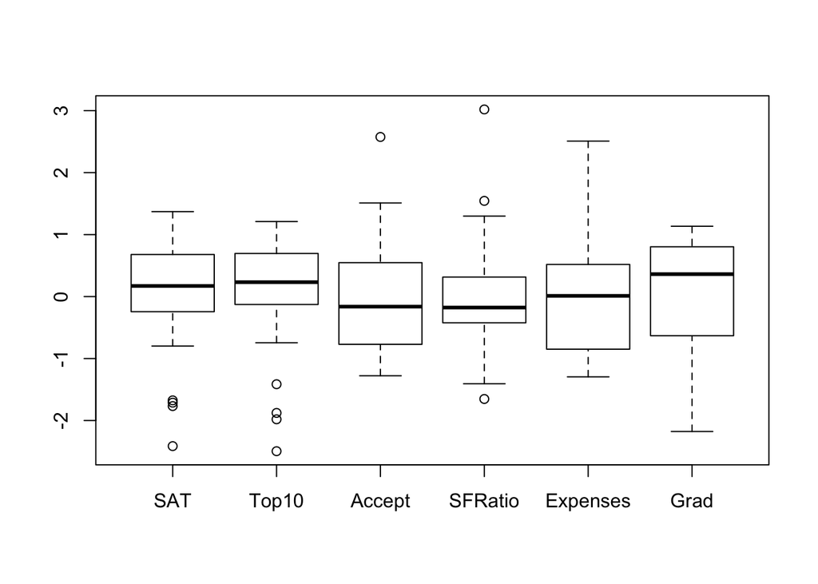

It seems there are four or five clusters in the first method, which is supported by the hclus_eval as well. The dendrogram supports five, but our hypothesis of four is supported when considering the first two principal components.

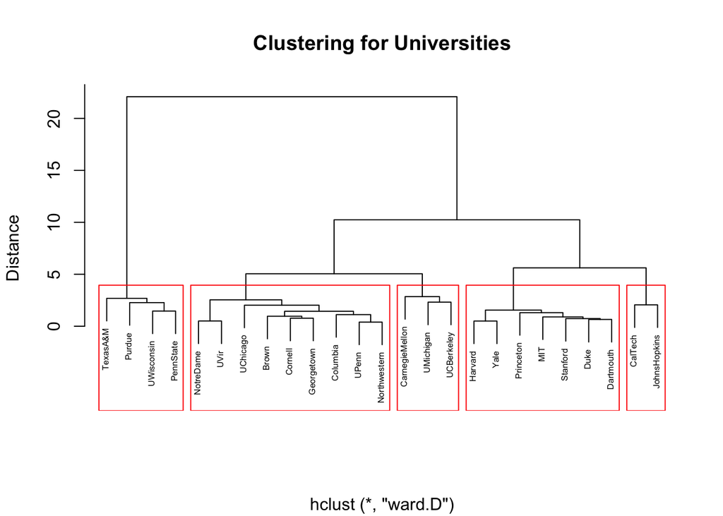

```
##        Harvard      Princeton           Yale       Stanford            MIT
##              1              1              1              1              1
##           Duke        CalTech      Dartmouth          Brown   JohnsHopkins
##              1              2              1              3              2
##       UChicago          UPenn        Cornell   Northwestern       Columbia
##              3              3              3              3              3
##      NotreDame           UVir     Georgetown CarnegieMellon      UMichigan
##              3              3              3              3              3
##     UCBerkeley     UWisconsin      PennState         Purdue       TexasA&M
##              3              4              4              4              4
```

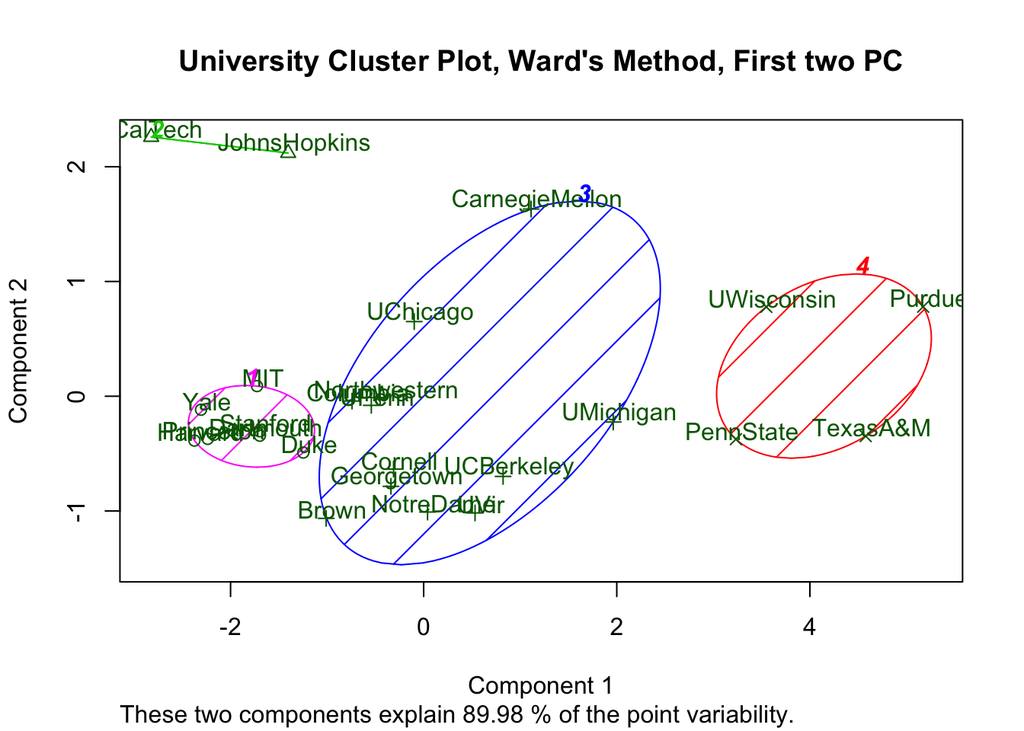

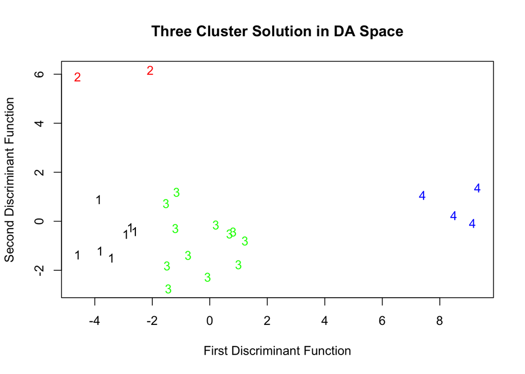

```
## [1] "Creating Distance Matrix using euclidean"
## [1] "Clustering using ward.D"
## [1] "Clustering Complete. Access the Cluster object in first element of output"
## [1] "Calculating RMSSTD"
## [1] "RMSSTD Done. Access in Element 2"
## [1] "Calculating RSQ"
## [1] "RSQ Done. Access in Element 3"
## [1] "Calculating SPRSQ"
## [1] "SPRSQ Done. Access in Element 4"
## [1] "Calculating Cluster Dist. "
## [1] "CD Done. Access in Element 5"
```

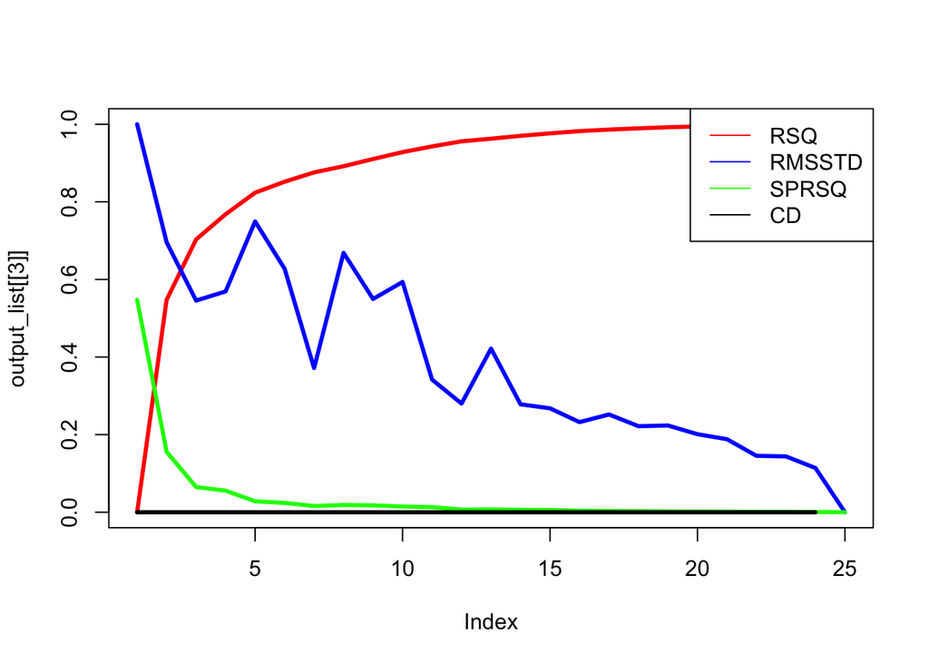

```
## [[1]]
##
## Call:
## hclust(d = dist1, method = clus_m)
##
## Cluster method   : ward.D
## Distance         : euclidean
## Number of objects: 25
##
##
## [[2]]
##  [1] 1.0000000 0.6957217 0.5455504 0.5690948 0.7494865 0.6275674 0.3716089
##  [8] 0.6684786 0.5496442 0.5934966 0.3418013 0.2801410 0.4217875 0.2781637
## [15] 0.2678412 0.2322383 0.2519726 0.2217753 0.2235236 0.2010975 0.1882320
## [22] 0.1453734 0.1439020 0.1139935 0.0000000
##
## [[3]]
##  [1] 0.0000000 0.5474127 0.7031216 0.7680337 0.8236317 0.8518232 0.8758776
##  [8] 0.8918210 0.9104404 0.9282034 0.9428800 0.9559672 0.9627676 0.9701803
## [15] 0.9765147 0.9823232 0.9862763 0.9894854 0.9922634 0.9943452 0.9962389
## [22] 0.9977152 0.9985957 0.9994586 1.0000000
##
## [[4]]
##  [1] 0.5474127146 0.1557088738 0.0649120744 0.0555979982 0.0281915177
##  [6] 0.0240543736 0.0159434824 0.0186193184 0.0177630311 0.0146765903
## [11] 0.0130872221 0.0068004396 0.0074126959 0.0063344024 0.0058084457
## [16] 0.0039531123 0.0032090666 0.0027780177 0.0020817835 0.0018937129
## [21] 0.0014763040 0.0008805596 0.0008628244 0.0005414387 0.0000000000
##
## [[5]]
##  [1] 0 0 0 0 0 0 0 0 0 0 0 0 0 0 0 0 0 0 0 0 0 0 0 0
```

Four/five cluster approaches capture the “outliers” of Caltech and Johns Hopkins. In our second method, below, three clusters makes the most sense.

Using four splits Caltech and Johns Hopkins but combines Columbia and Georgetown, which seem to have less in common. We are have less confidence in this method compared to the first since the cluster divisions fall in between Universities on the “lowest branches,” e.g. Purdue and Texas A&M.

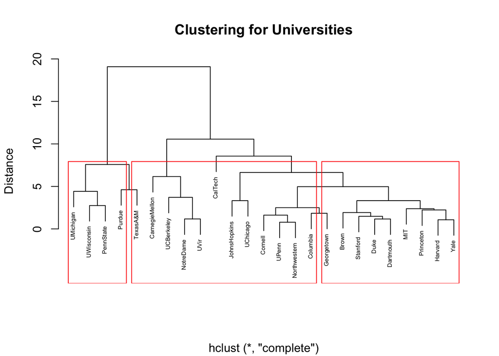

```
##        Harvard      Princeton           Yale       Stanford            MIT
##              1              1              1              1              1
##           Duke        CalTech      Dartmouth          Brown   JohnsHopkins
##              1              1              1              1              1
##       UChicago          UPenn        Cornell   Northwestern       Columbia
##              1              1              1              1              1
##      NotreDame           UVir     Georgetown CarnegieMellon      UMichigan
##              2              2              1              2              3
##     UCBerkeley     UWisconsin      PennState         Purdue       TexasA&M
##              2              3              3              3              3
```

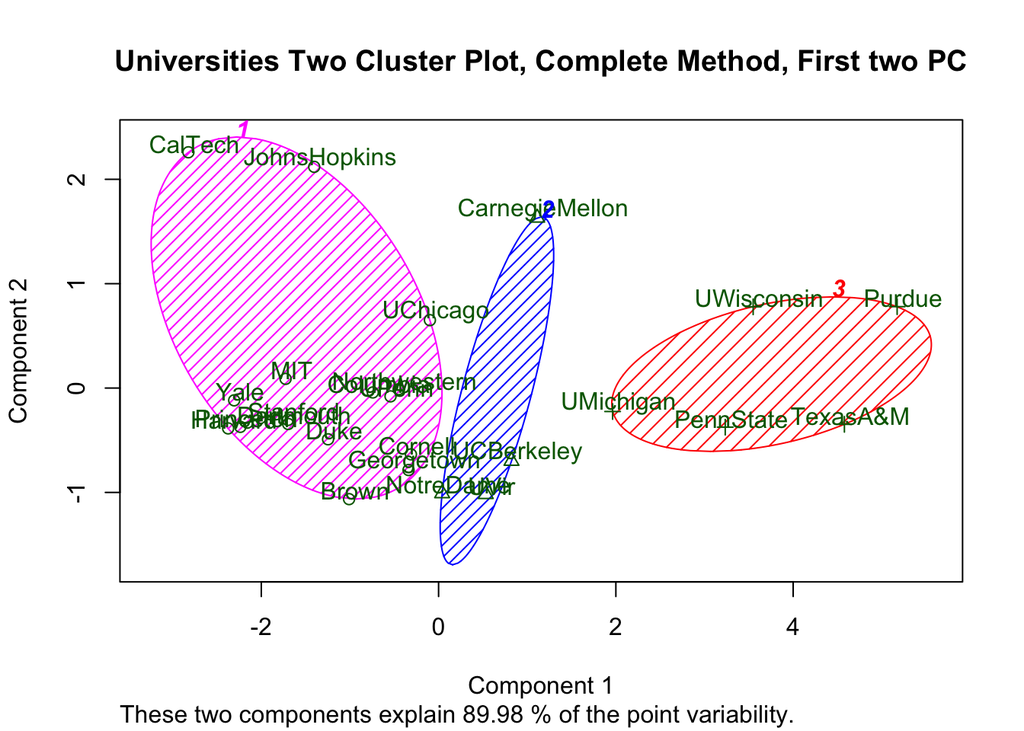

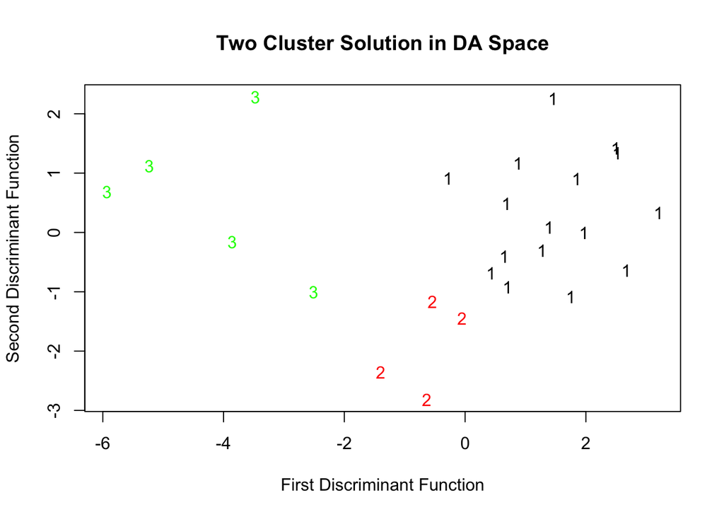

```
## [1] "Creating Distance Matrix using manhattan"
## [1] "Clustering using complete"
## [1] "Clustering Complete. Access the Cluster object in first element of output"
## [1] "Calculating RMSSTD"
## [1] "RMSSTD Done. Access in Element 2"
## [1] "Calculating RSQ"
## [1] "RSQ Done. Access in Element 3"
## [1] "Calculating SPRSQ"
## [1] "SPRSQ Done. Access in Element 4"
## [1] "Calculating Cluster Dist. "
## [1] "CD Done. Access in Element 5"
```

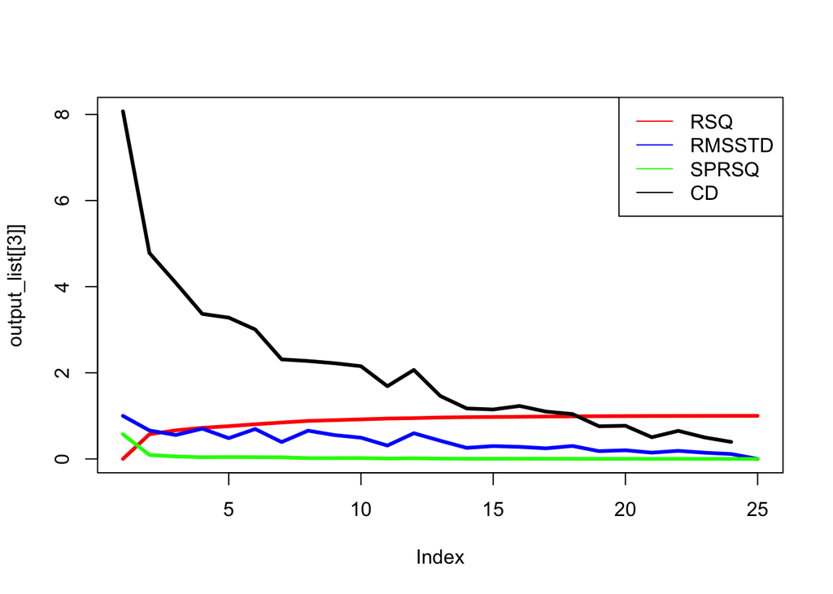

```
## [[1]]
##
## Call:
## hclust(d = dist1, method = clus_m)
##
## Cluster method   : complete
## Distance         : manhattan
## Number of objects: 25
##
##
## [[2]]
##  [1] 1.0000000 0.6604497 0.5553092 0.7027735 0.4819105 0.6945914 0.3915882
##  [8] 0.6563649 0.5533327 0.4931768 0.3107139 0.5965445 0.4217875 0.2567221
## [15] 0.2982897 0.2800189 0.2457604 0.3008404 0.1808557 0.2010975 0.1453734
## [22] 0.1882320 0.1439020 0.1139935 0.0000000
##
## [[3]]
##  [1] 0.0000000 0.5723648 0.6646476 0.7219057 0.7607555 0.8047291 0.8447676
##  [8] 0.8822955 0.9002461 0.9183482 0.9377362 0.9472228 0.9620505 0.9694632
## [15] 0.9739508 0.9785387 0.9842101 0.9883898 0.9921609 0.9943452 0.9962389
## [22] 0.9971194 0.9985957 0.9994586 1.0000000
##
## [[4]]
##  [1] 0.5723647737 0.0922827931 0.0572581767 0.0388497231 0.0439736076
##  [6] 0.0400385442 0.0375278783 0.0179506215 0.0181020605 0.0193880525
## [11] 0.0094865489 0.0148277223 0.0074126959 0.0044876054 0.0045878753
## [16] 0.0056713910 0.0041797578 0.0037710397 0.0021842929 0.0018937129
## [21] 0.0008805596 0.0014763040 0.0008628244 0.0005414387 0.0000000000
##
## [[5]]
##  [1] 8.0714998 4.7822435 4.0861104 3.3672088 3.2805612 3.0064051 2.3114020
##  [8] 2.2737148 2.2222077 2.1531056 1.6882067 2.0664907 1.4611148 1.1716344
## [15] 1.1485169 1.2297027 1.0984372 1.0421418 0.7583965 0.7693644 0.5035883
## [22] 0.6520549 0.4984911 0.3948852
```

As mentioned above there appears to be three to five clusters. Attempting to use more than five leads to unusual groupings. We plan to retain three clusters.

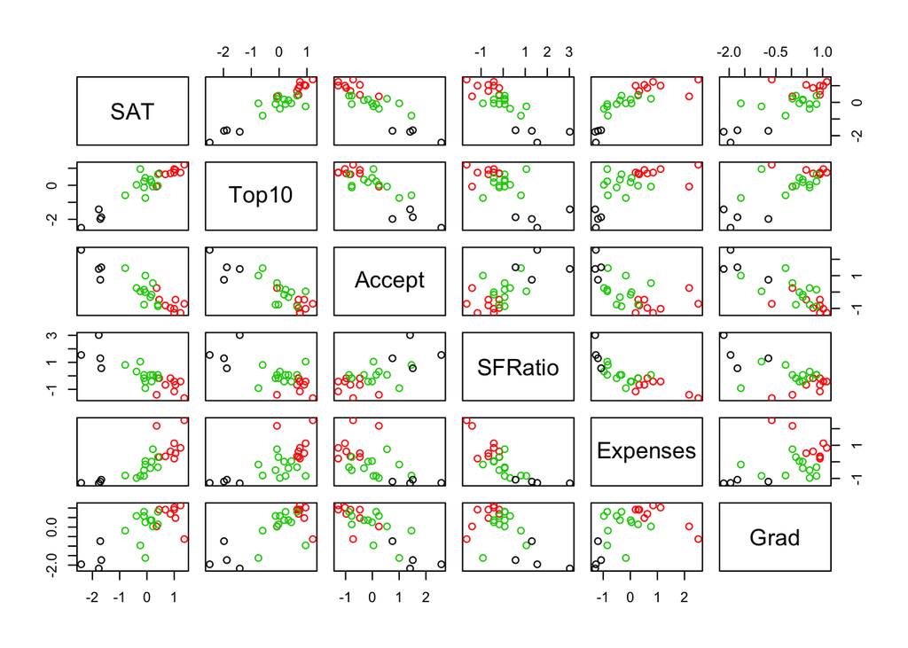

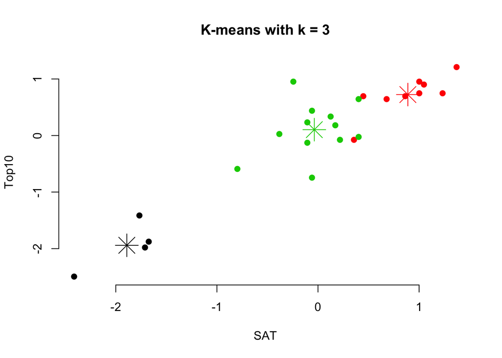

```
## [1] "Universities in Cluster  1"
## [1] "UWisconsin" "PennState"  "Purdue"     "TexasA&M"
## [1] "Universities in Cluster  2"
## [1] "Harvard"      "Princeton"    "Yale"         "Stanford"
## [5] "MIT"          "Duke"         "CalTech"      "Dartmouth"
## [9] "JohnsHopkins"
## [1] "Universities in Cluster  3"
##  [1] "Brown"          "UChicago"       "UPenn"          "Cornell"
##  [5] "Northwestern"   "Columbia"       "NotreDame"      "UVir"
##  [9] "Georgetown"     "CarnegieMellon" "UMichigan"      "UCBerkeley"
```

```
## 2-cluster solution HROT: 30.78416
## 3-cluster solution HROT: 9.689657
## 4-cluster solution HROT: 6.78741
## 5-cluster solution HROT: 5.442467
## 6-cluster solution HROT: 3.614863
## 7-cluster solution HROT: 3.545544
## 8-cluster solution HROT: 3.071527
## 9-cluster solution HROT: 3.271641
## 10-cluster solution HROT: 3.255272
## 11-cluster solution HROT: 2.859396
## 12-cluster solution HROT: 4.266547
## 13-cluster solution HROT: 2.805414
## 14-cluster solution HROT: 2.34752
## 15-cluster solution HROT: 1.990926
## 16-cluster solution HROT: 3.683246
## 17-cluster solution HROT: 2.304399
## 18-cluster solution HROT: 2.323722
## 19-cluster solution HROT: 1.990611
## 20-cluster solution HROT: 1.84071
```

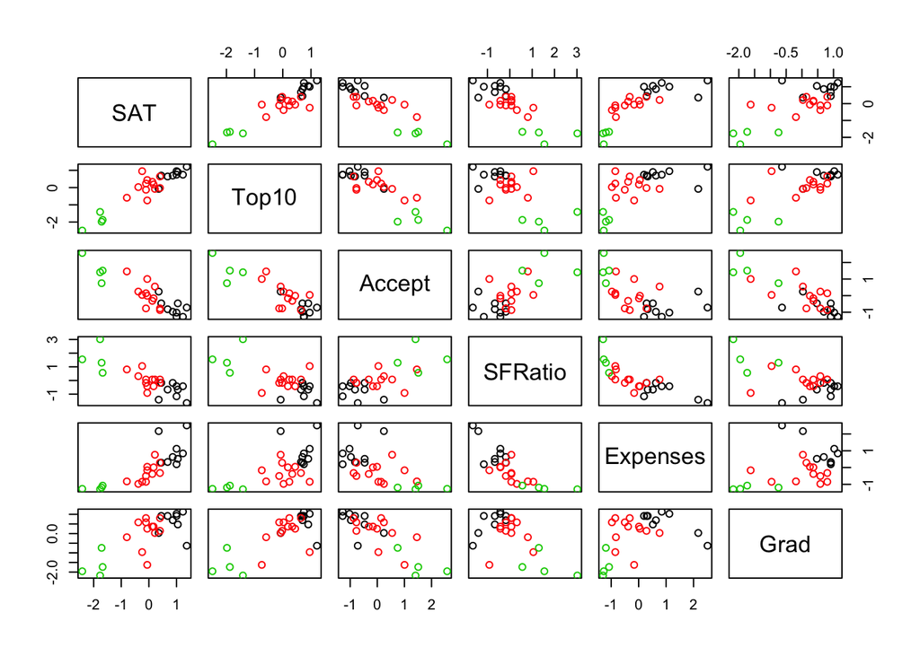

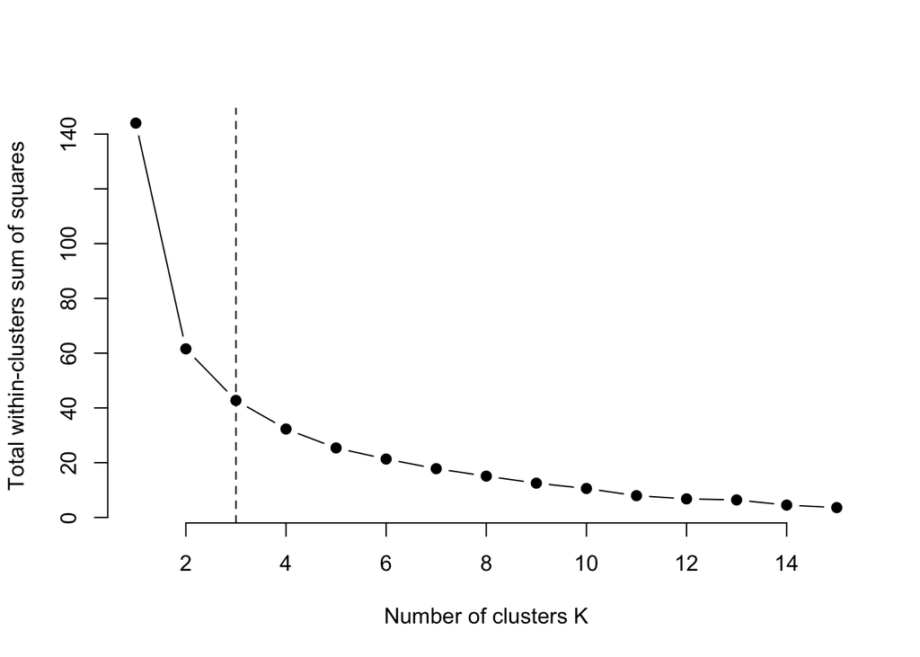

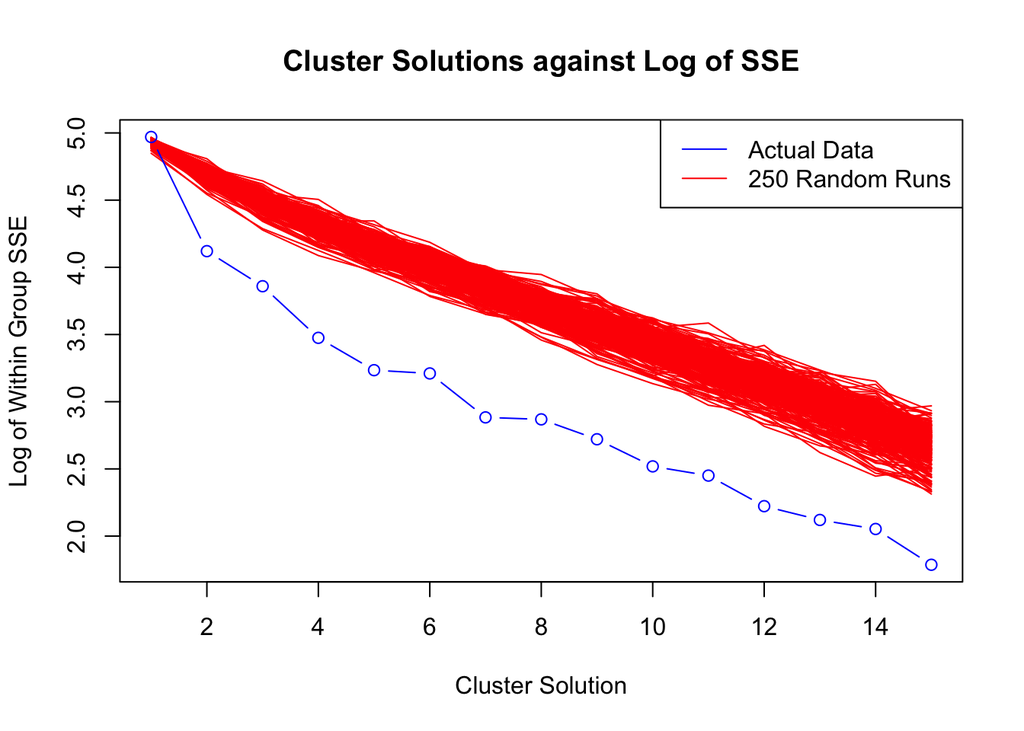

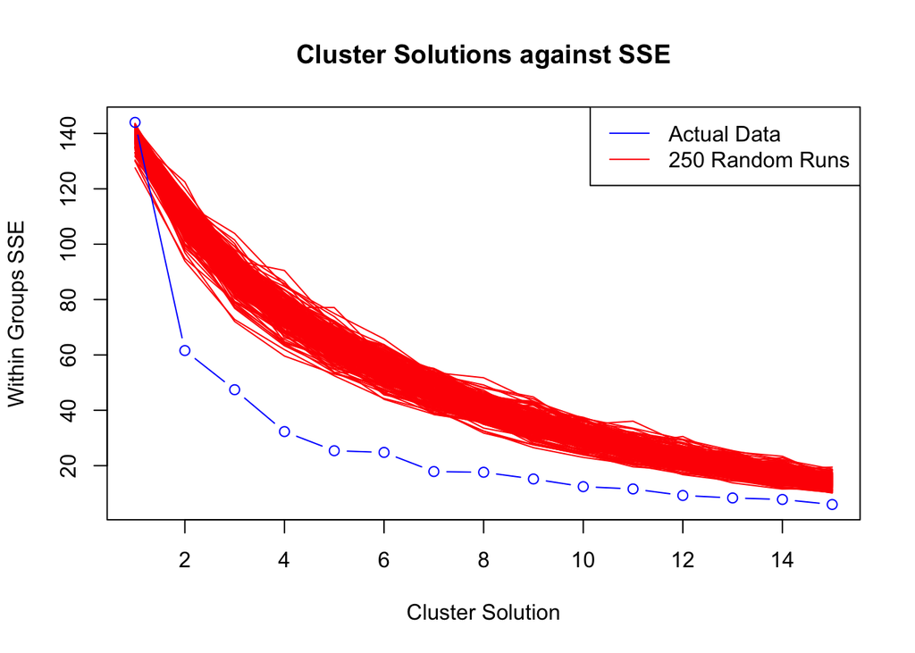

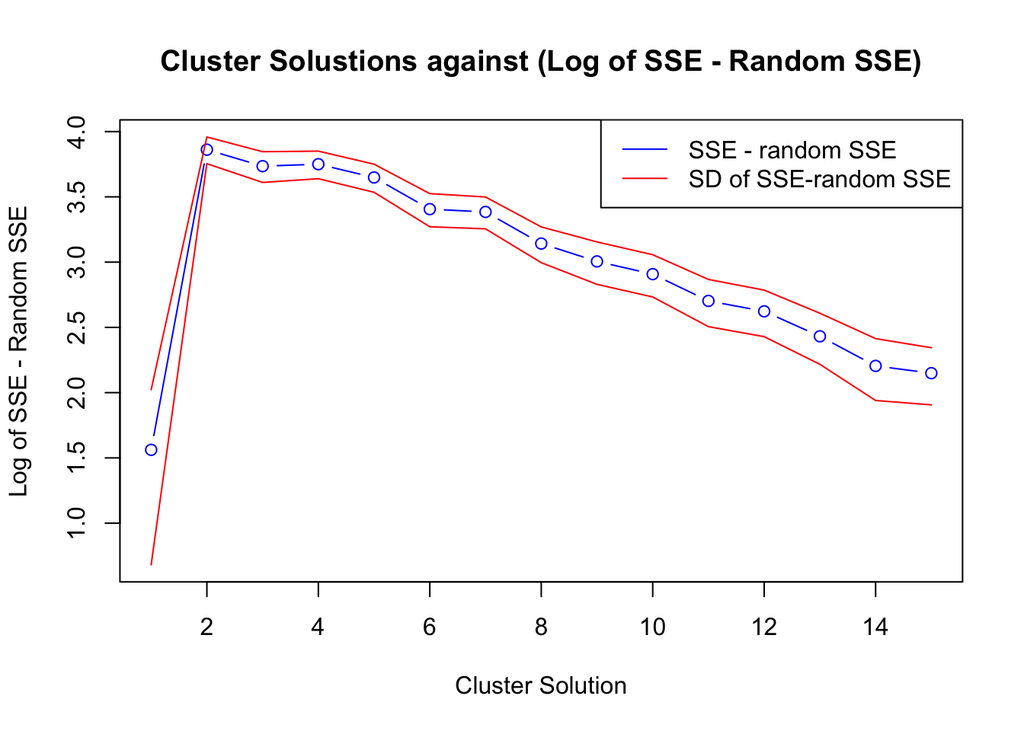

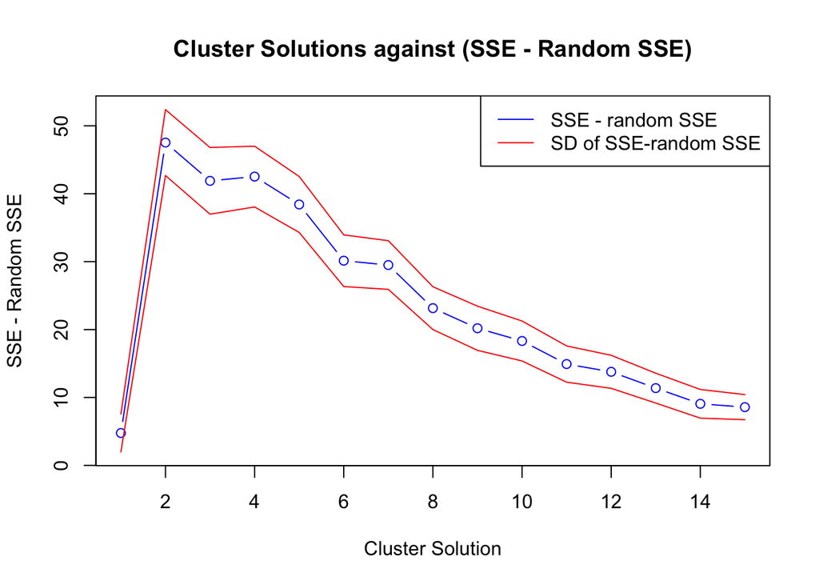

We believe there are three clusters present based on the information provided above. The visualizations and k-means analysis correspond to this number. Further analysis could be done using discriminant analysis to verfiy our decisions.